# R Notebook

```r
require(fUnitRoots)
require(urca)
require(MTS)
da=read.table("m-bnd.txt")
head(da)
```

|  | V1 | V2 | V3 | V4 | V5 |
| --- | --- | --- | --- | --- | --- |
| 1 | 1954 | 7 | 1 | 2.89 | 3.50 |
| 2 | 1954 | 8 | 1 | 2.87 | 3.49 |
| 3 | 1954 | 9 | 1 | 2.89 | 3.47 |
| 4 | 1954 | 10 | 1 | 2.87 | 3.46 |
| 5 | 1954 | 11 | 1 | 2.89 | 3.45 |
| 6 | 1954 | 12 | 1 | 2.90 | 3.45 |

```r
tail(da)
```

|  | V1 | V2 | V3 | V4 | V5 |
| --- | --- | --- | --- | --- | --- |
| 604 | 2004 | 10 | 1 | 5.47 | 6.21 |
| 605 | 2004 | 11 | 1 | 5.52 | 6.20 |
| 606 | 2004 | 12 | 1 | 5.47 | 6.15 |
| 607 | 2005 | 1 | 1 | 5.36 | 6.02 |
| 608 | 2005 | 2 | 1 | 5.20 | 5.82 |
| 609 | 2005 | 3 | 1 | 5.40 | 6.06 |

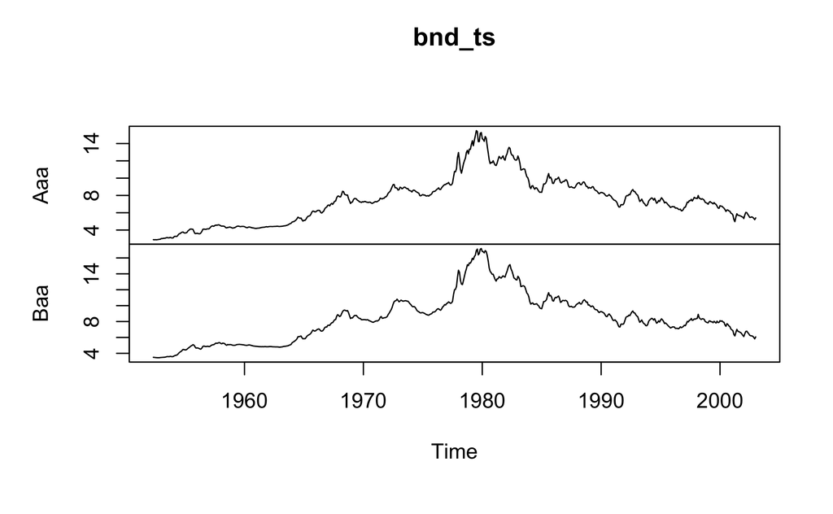

```r
bnd=da[,4:5]
colnames(bnd) <- c("Aaa","Baa")
bnd_ts=ts(bnd,start=c(1952,5),frequency = 12)
plot(bnd_ts)
```

```r
ar(bnd[,1]) ##Selecciona un modelo AR usando el crierio de Akaike  a la serie Aaa
```

```
Call:
ar(x = bnd[, 1])

Coefficients:
      1        2        3
 1.2217  -0.3301   0.1017

Order selected 3  sigma^2 estimated as  0.085
```

```r
ar(bnd[,2]) ##Selecciona un modelo AR usando el crierio de Akaike a la serie Baa
```

```
Call:
ar(x = bnd[, 2])

Coefficients:
      1        2
 1.2129  -0.2188

Order selected 2  sigma^2 estimated as  0.08477
```

```r
##Para la serie Aaa
nn1 <- ur.df(bnd[,1],lags=3,type="none")
summary(nn1) ###No se rechaza la hipótesis nula de la presencia de raíz unitaria
```

```
###############################################
# Augmented Dickey-Fuller Test Unit Root Test #
###############################################

Test regression none


Call:
lm(formula = z.diff ~ z.lag.1 - 1 + z.diff.lag)

Residuals:
     Min       1Q   Median       3Q      Max
-0.99473 -0.07876  0.00404  0.08486  1.09115

Coefficients:
              Estimate Std. Error t value Pr(>|t|)
z.lag.1     -0.0001961  0.0010330  -0.190    0.849
z.diff.lag1  0.4622313  0.0407870  11.333  < 2e-16 ***
z.diff.lag2 -0.2798201  0.0434972  -6.433 2.55e-10 ***
z.diff.lag3  0.0534140  0.0408121   1.309    0.191
---
Signif. codes:  0 ‘***’ 0.001 ‘**’ 0.01 ‘*’ 0.05 ‘.’ 0.1 ‘ ’ 1

Residual standard error: 0.201 on 601 degrees of freedom
Multiple R-squared:  0.1866,    Adjusted R-squared:  0.1811
F-statistic: 34.46 on 4 and 601 DF,  p-value: < 2.2e-16


Value of test-statistic is: -0.1899

Critical values for test statistics:
      1pct  5pct 10pct
tau1 -2.58 -1.95 -1.62
```

```r
##Para la serie Baa
nn2 <- ur.df(bnd[,2],lags=2,type="none")
summary(nn2)###No se rechaza la hipótesis nula de la presencia de raíz unitaria
```

```
###############################################
# Augmented Dickey-Fuller Test Unit Root Test #
###############################################

Test regression none


Call:
lm(formula = z.diff ~ z.lag.1 - 1 + z.diff.lag)

Residuals:
     Min       1Q   Median       3Q      Max
-0.75087 -0.06858  0.00281  0.07989  0.97772

Coefficients:
              Estimate Std. Error t value Pr(>|t|)
z.lag.1     -0.0001384  0.0008207  -0.169 0.866140
z.diff.lag1  0.5128883  0.0403612  12.707  < 2e-16 ***
z.diff.lag2 -0.1520575  0.0404058  -3.763 0.000184 ***
---
Signif. codes:  0 ‘***’ 0.001 ‘**’ 0.01 ‘*’ 0.05 ‘.’ 0.1 ‘ ’ 1

Residual standard error: 0.1801 on 603 degrees of freedom
Multiple R-squared:  0.2159,    Adjusted R-squared:  0.212
F-statistic: 55.35 on 3 and 603 DF,  p-value: < 2.2e-16


Value of test-statistic is: -0.1686

Critical values for test statistics:
      1pct  5pct 10pct
tau1 -2.58 -1.95 -1.62
```

```r
###Qué VAR orden del VAR se debería seleccionar en principio para chequear el rango de Co-integración?
MTS::VARorder(bnd)
```

```
selected order: aic =  11
selected order: bic =  3
selected order: hq =  3
Summary table:
       p     AIC     BIC      HQ      M(p) p-value
 [1,]  0 -0.5697 -0.5697 -0.5697    0.0000  0.0000
 [2,]  1 -7.8664 -7.8374 -7.8551 4331.0806  0.0000
 [3,]  2 -8.1844 -8.1264 -8.1618  195.5266  0.0000
 [4,]  3 -8.2589 -8.1720 -8.2251   51.6109  0.0000
 [5,]  4 -8.2552 -8.1393 -8.2101    5.5112  0.2387
 [6,]  5 -8.2481 -8.1032 -8.1917    3.5073  0.4768
 [7,]  6 -8.2751 -8.1013 -8.2075   23.4161  0.0001
 [8,]  7 -8.2803 -8.0775 -8.2014   10.6262  0.0311
 [9,]  8 -8.2826 -8.0507 -8.1924    8.9080  0.0634
[10,]  9 -8.2784 -8.0176 -8.1769    5.1613  0.2711
[11,] 10 -8.2775 -7.9877 -8.1648    7.0457  0.1335
[12,] 11 -8.2840 -7.9652 -8.1600   11.2224  0.0242
[13,] 12 -8.2812 -7.9334 -8.1459    5.8956  0.2071
[14,] 13 -8.2716 -7.8949 -8.1251    2.0355  0.7292
```

###Prueba de co-integración

Llevaremos a cabo las 2 pruebas de cointegración

[figure not shown]

$ L_{max}(0)=24.37$ y los cuantiles 10pct:13.75 5pct:15.67 1pct:20.20

$ L_{max}(1)=3.73$ y los cuantiles 10pct:7.52 5pct:9.24 1pct:12.97

La conclusión sería que el rango es $m=1$ porque se rechazó $H_0:Rango(\Pi)=m=0$ v.s $H_a:Rango(\Pi)>0$. Note que acá la relación de cointegración queda de la siguiente forma:

$$w_t=(1,-0.89349671,0.05925493)(1,z_t')'$$

Análogamente, para la prueba de traza tenemos que:

$ L_{tr}(0)=28.10$ y los cuantiles 10pct:17.85 5pct:19.96 1pct:24.60

$ L_{tr}(1)=3.73$ y los cuantiles 10pct:7.52 5pct:9.24 1pct:12.97

La conclusión también sería que el rango es $m=1$ porque se rechazó $H_0:Rango(\Pi)=m=0$ v.s $H_a:Rango(\Pi)=m+1=1$